# Homework 2

JEREMY KNOX PSTAT 231, W19

February 10, 2019

# K-Nearest Neighbor Method

#### Problem 1: Cross Validation 10 times with do chunk for each nieghbor (K) to find best K

| train.error | val.error | neighbor |
| --- | --- | --- |
| 0.0003086420 | 0.09695291 | 1 |
| 0.0000000000 | 0.10555556 | 1 |
| 0.0003085467 | 0.08611111 | 1 |
| 0.0003085467 | 0.13055556 | 1 |
| 0.0000000000 | 0.09166667 | 1 |
| 0.0000000000 | 0.11388889 | 1 |
| 0.0003085467 | 0.08611111 | 1 |
| 0.0006170935 | 0.10555556 | 1 |
| 0.0006170935 | 0.09444444 | 1 |
| 0.0006170935 | 0.10277778 | 1 |

[output cut: 50 more lines]

| neighbor | train.error | val.error |
| --- | --- | --- |
| 1 | 0.0003085563 | 0.1013620 |
| 10 | 0.0835569535 | 0.0991382 |
| 20 | 0.0950353305 | 0.1046953 |
| 30 | 0.1035823515 | 0.1138596 |
| 40 | 0.1137956297 | 0.1196914 |
| 50 | 0.1180536605 | 0.1221891 |

```
## [1] 10
```

BEST K = 10

#### Problem 2: Find error on optimal K

```
##          train.error test.error
## knn       0.07914468      0.094
## tree              NA         NA
## logistic          NA         NA
```

# Decision Tree Method

#### Problem 3: Make Tree

Terminal Nodes 184  
Misclassified Training Observations 48

#### Problem 4: Pruning the Tree

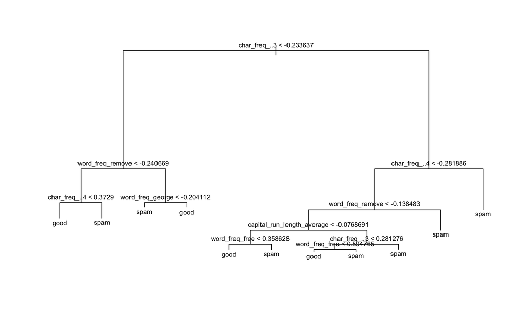

#### Problem 5: 10-Fold Cross Validation on Tree. Size vs. Misclassification Error

```
## [1] 76
```

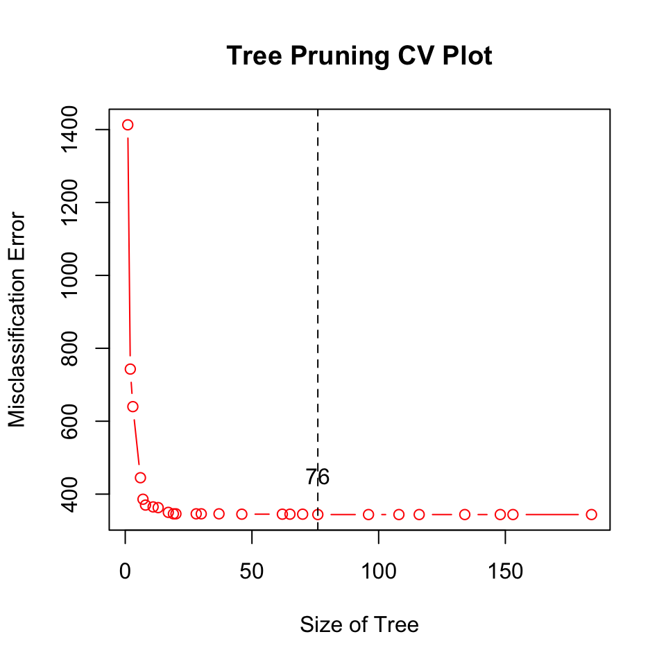

#### Problem 6: Training and Test Errors

```
##          train.error test.error
## knn       0.07914468      0.094
## tree      0.02943627      0.061
## logistic          NA         NA
```

# Logisitc Regression

#### Problem 7:

###### b. Link Function

Assume $z = \beta_0 + \beta_1 x_1$ and $p = logistic(z)$ from above and $\text{odds: } \frac{p}{1-p}$, then
$$\begin{aligned}
\frac{p}{1-p}&=\frac{\frac{e^z}{1+e^z}}{1-\frac{e^z}{1+e^z}}\\
&=\frac{\frac{e^z}{1+e^z}}{\frac{1}{1+e^z}}\\
&=e^z\\
\end{aligned}$$
Which implies $\text{odds } = e^{\beta_0} e^{\beta_1 x_1}$

Let $2x_1$, then we have
$$\begin{aligned}
&=\frac{e^{\beta_0} e^{\beta_1 (x_1+2)}}{e^{\beta_0} e^{\beta_1 x_1}}\\
&=e^{2 \beta_1}
\end{aligned}$$
Thus a two times increase of $x_1$ gives us $2x_1 \implies e^{2 \beta_1}$.

For $\beta_1 < 0$, what does $p$ approach as $x_1 \rightarrow \infty$? We have $p = \frac{e^{\beta_0} e^{\beta_1 x_1}}{1+e^{\beta_0} e^{\beta_1 x_1}}$
$$\begin{aligned}
\lim_{x_1\to\infty} p &=\frac{\lim_{x_1\to\infty} e^{\beta_0} e^{\beta_1 x_1}}{1+\lim_{x_1\to\infty} e^{\beta_0} e^{\beta_1 x_1}}\\
&= \frac{0}{1+0}\\
&= 0\\
\end{aligned}\\$$
Thus we have, $p$ approaches $0$ as $x_1 \rightarrow \infty$.

For $\beta_1 < 0$, what does $p$ approach as $x_1 \rightarrow -\infty$? We have $p = \frac{e^{\beta_0} e^{\beta_1 x_1}}{1+e^{\beta_0} e^{\beta_1 x_1}}$
$$\begin{aligned}
\lim_{x_1\to\infty} p &=\frac{\lim_{x_1\to\infty} e^{\beta_0} e^{\beta_1 x_1}}{\lim_{x_1\to\infty}1+e^{\beta_0} e^{\beta_1 x_1}}\\
&= \frac{\infty}{\infty}\\
\end{aligned}\\$$
Apply L’Hospital $\mathop {\lim }\limits_{x \to c} \frac{{f\left( x \right)}}{{g\left( x \right)}} = \mathop {\lim }\limits_{x \to c} \frac{{f'\left( x \right)}}{{g'\left( x \right)}}$:
$$\begin{aligned}
\lim_{x_1\to\infty} p &= \lim_{x_1\to\infty}\frac{e^{\beta_0} \beta_1 e^{\beta_1 x_1}}{e^{\beta_0} \beta_1 e^{\beta_1 x_1}}\\
&= \lim_{x_1\to\infty} 1\\
&= 1\\
\end{aligned}\\$$
Thus, $p$ approaches $1$ as $x_1 \rightarrow -\infty$.

#### Problem 8: Classify with Logistic and obtain Training and Test Error

```
##                train.good.real
## train.good.pred FALSE TRUE
##           FALSE  2087  154
##           TRUE    101 1259
```

```
## [1] 0.07081366
```

```
##               test.good.real
## test.good.pred FALSE TRUE
##          FALSE   574   55
##          TRUE     26  345
```

```
## [1] 0.081
```

```
##          train.error test.error
## knn       0.07914468      0.094
## tree      0.02943627      0.061
## logistic  0.07081366      0.081
```

TREE model has lowest test.error of 0.061

#### Problem 9: ROC Curves for Tree v Logistic

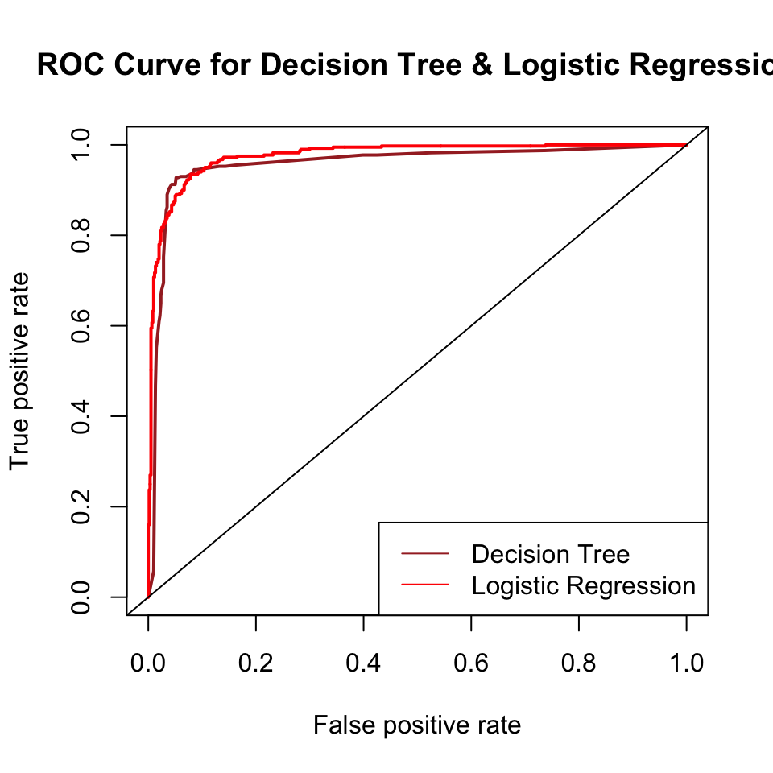

```
## [[1]]
## [1] 0.9578583
```

```
## [[1]]
## [1] 0.9758875
```

#### Problem 10:

When considering time spent on email, efficieny and accuracy are usually negatively correlated. However, accuracy oftern supersedes efficieny. Thus false positives would be the main concern. Emails that get marked as “spam” that are not can be very bad for the customer of this spam filter.

#### Problem 11: Multivariate Normal

If $\hat{Y}=1$, then $P(Y=1|X=x) > T$
$$\begin{aligned}
\frac{f_1(x) \pi_1}{f_1(x) \pi_1 + f_2(x) \pi_2} &> T\\
\frac{1}{1+\frac{f_2(x) \pi_2}{f_1(x) \pi_1}} &> T\\
\frac{1}{T} &> 1+\frac{f_2(x) \pi_2}{f_1(x) \pi_1}\\
\frac{1-T}{T} &> \frac{f_2(x) \pi_2}{f_1(x) \pi_1}\\
log(\pi_1)+log(f_1(x))-log(\pi_2)-log(f_2(x)) &> log(\frac{T}{1-T}) \\
\text{expanding the log we get} \\
log(f_k(x)) &= -\frac{1}{2}log(|\Sigma_{k}^{-1}|)+log(\pi_k) \\
\text{substituting in } log(f_k(x)) \ k=1,2 \\
- \frac{1}{2}(x-\mu_1)^T\Sigma_{1}^{-1}(x-\mu_1) -\frac{1}{2}log(|\Sigma_{1}^{-1}|)+log(\pi_1)\\
+ \frac{1}{2}(x-\mu_2)^T\Sigma_{2}^{-1}(x-\mu_2) +\frac{1}{2}log(|\Sigma_{2}^{-1}|)-log(\pi_2) &> log(\frac{T}{1-T})\\
\delta_1(x)-\delta_2(x) &> log(\frac{T}{1-T})\\
\end{aligned}\\$$
Let $M(T) = log(\frac{T}{1-T})$, then $\delta_1(x)-\delta_2(x) > M(T)$. When the thresshold $p = \frac{1}{2}, \text{then } M(\frac{1}{2})=log\Bigg( \frac{\frac{1}{2}}{1-\frac{1}{2}} \Bigg) = 0$. When the probability threshold is $\frac{1}{2}$ we have a decision threshold of $0$.

#### Problem 12: Variable Standardization and Discretization

```r
algae = mutate_at(algae, vars(colnames[4:11]),
                   funs(log(.))) # log transform
algae = mutate_at(algae, vars(colnames[4:11]),
                       funs(ifelse(is.na(.), median(algae$.,na.rm=TRUE), .))) # repalce NA's with medians
algae = mutate_at(algae, vars(a1), funs(ifelse(.>0.5,"High","Low"))) # a1 as factor
```

#### Problem 13. Linear and Quadratic Discriminant Analysis

###### b) QDA

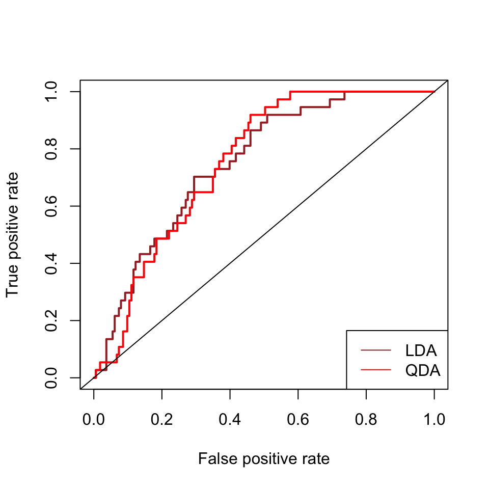

```
## [[1]]
## [1] 0.7517825
```

```
## [[1]]
## [1] 0.7534406
```

AUC of QDA is 0.753 vs. LDA of 0.751, thus the “better” model is QDA.